## Machine learning project: Classfication methods using R Samson Oni (soni5@umbc.edu) April 9, 2019

# 1 Introduction

This document reports the analysis of local stability electric grid dataset, hosted by UCI Machinelearning repository. The data set contains readings from an electrical system having 4 nodes producing electricity and using the data to determine the system stability. Goal is to model the data, so as to accurately predict the stability of electric grid. Also, infer the relationship between predictors and the response.The URL of the dataset is https://archive.ics.uci.edu/ml/datasets/Electrical+Grid+Stability+Simulated+Data+.

*Size of Observations(n)* = 10000

*Number of predictors(p)* = 11

**What constitutes an observation**: Each observation represents valuation record of a system using multiple nodes. There are 11 predictor variables and 1 outcome variable for each observation.The predictor variables usage are independent on each other.

**Response Variables**: The Response variable also known as the Output variable is stabf.It tells us if the system is stable or not.

Below shows the data features and some of its observations.

```r
names(data)
```

```
##  [1] "tau1"  "tau2"  "tau3"  "tau4"  "p2"    "p3"    "p4"    "g1"
##  [9] "g2"    "g3"    "g4"    "stabf"
```

```r
head(data)
```

```
##        tau1     tau2     tau3     tau4         p2         p3         p4
## 1 2.9590600 3.079885 8.381025 9.780754 -0.7826036 -1.2573948 -1.7230863
## 2 9.3040972 4.902524 3.047541 1.369357 -1.9400584 -1.8727417 -1.2550120
## 3 8.9717069 8.848428 3.046479 1.214518 -1.2074556 -1.2772101 -0.9204924
## 4 0.7164148 7.669600 4.486641 2.340563 -1.0274733 -1.9389442 -0.9973736
## 5 3.1341116 7.608772 4.943759 9.857573 -1.1255310 -1.8459749 -0.5543050
## 6 6.9992087 9.109247 3.784066 4.267788 -1.8571392 -0.6703968 -1.9021328
##          g1         g2        g3        g4    stabf
## 1 0.6504565 0.85957811 0.8874449 0.9580340 unstable
## 2 0.4134406 0.86241408 0.5621391 0.7817599   stable
## 3 0.1630410 0.76668866 0.8394440 0.1098532 unstable
## 4 0.4462089 0.97674408 0.9293805 0.3627178 unstable
## 5 0.7971095 0.45544995 0.6569467 0.8209235 unstable
## 6 0.2617929 0.07792967 0.5428839 0.4699310   stable
```

```r
dim(data)
```

```
## [1] 10000    12
```

dim() function shows the data has 10000 observations and 12 columns.

Below shows the summary of the data set. The summary() function produces a numerical summary of each variable in the data.

```r
summary(data)
```

```
##       tau1             tau2              tau3             tau4
##  Min.   :0.5008   Min.   : 0.5001   Min.   :0.5008   Min.   :0.5005
##  1st Qu.:2.8749   1st Qu.: 2.8751   1st Qu.:2.8755   1st Qu.:2.8750
##  Median :5.2500   Median : 5.2500   Median :5.2500   Median :5.2497
##  Mean   :5.2500   Mean   : 5.2500   Mean   :5.2500   Mean   :5.2500
##  3rd Qu.:7.6247   3rd Qu.: 7.6249   3rd Qu.:7.6249   3rd Qu.:7.6248
##  Max.   :9.9995   Max.   : 9.9998   Max.   :9.9994   Max.   :9.9994
##        p2                p3                p4                g1
##  Min.   :-1.9999   Min.   :-1.9999   Min.   :-1.9999   Min.   :0.05001
##  1st Qu.:-1.6249   1st Qu.:-1.6250   1st Qu.:-1.6250   1st Qu.:0.28752
##  Median :-1.2500   Median :-1.2500   Median :-1.2500   Median :0.52501
##  Mean   :-1.2500   Mean   :-1.2500   Mean   :-1.2500   Mean   :0.52500
##  3rd Qu.:-0.8750   3rd Qu.:-0.8750   3rd Qu.:-0.8751   3rd Qu.:0.76243
##  Max.   :-0.5001   Max.   :-0.5001   Max.   :-0.5000   Max.   :0.99994
##        g2                g3                g4               stabf
##  Min.   :0.05005   Min.   :0.05005   Min.   :0.05003   stable  :3620
##  1st Qu.:0.28755   1st Qu.:0.28751   1st Qu.:0.28749   unstable:6380
##  Median :0.52500   Median :0.52501   Median :0.52500
##  Mean   :0.52500   Mean   :0.52500   Mean   :0.52500
##  3rd Qu.:0.76249   3rd Qu.:0.76244   3rd Qu.:0.76243
##  Max.   :0.99994   Max.   :0.99998   Max.   :0.99993
```

The cor() functio below produces a matrix that contains all the pairwise correlations among the predictors in the data set.

```r
cor(data[,-12])
```

```
##              tau1         tau2         tau3          tau4           p2
## tau1  1.000000000  0.015585721 -0.005969607 -0.0172652888 -0.015485308
## tau2  0.015585721  1.000000000  0.014273414 -0.0019647158  0.006573472
## tau3 -0.005969607  0.014273414  1.000000000  0.0043543363 -0.003134261
## tau4 -0.017265289 -0.001964716  0.004354336  1.0000000000  0.010552963
## p2   -0.015485308  0.006573472 -0.003134261  0.0105529626  1.000000000
## p3   -0.015923767  0.007672768 -0.008780459  0.0061687215  0.002388424
## p4   -0.015807066 -0.005962636 -0.017531089 -0.0112110679 -0.006843659
## g1    0.010521128 -0.001742367 -0.011605048 -0.0041489273  0.015603017
## g2    0.015349831  0.015383308  0.007671386  0.0084310883 -0.018032104
## g3   -0.001278658  0.016508464  0.014701706  0.0032598572  0.007555052
## g4    0.005493873 -0.011764008 -0.011497448 -0.0004908815  0.019817004
##                p3           p4           g1           g2           g3
## tau1 -0.015923767 -0.015807066  0.010521128  0.015349831 -0.001278658
## tau2  0.007672768 -0.005962636 -0.001742367  0.015383308  0.016508464
## tau3 -0.008780459 -0.017531089 -0.011605048  0.007671386  0.014701706
## tau4  0.006168722 -0.011211068 -0.004148927  0.008431088  0.003259857
## p2    0.002388424 -0.006843659  0.015603017 -0.018032104  0.007555052
## p3    1.000000000  0.012952865 -0.003218925 -0.011574893 -0.005897288
## p4    0.012952865  1.000000000 -0.013635590  0.002849963 -0.003515084
## g1   -0.003218925 -0.013635590  1.000000000  0.007559018 -0.005836219
## g2   -0.011574893  0.002849963  0.007559018  1.000000000 -0.012808995
## g3   -0.005897288 -0.003515084 -0.005836219 -0.012808995  1.000000000
## g4   -0.010485250  0.017505439  0.012430613 -0.014909362  0.006900185
##                 g4
## tau1  0.0054938729
## tau2 -0.0117640085
## tau3 -0.0114974481
## tau4 -0.0004908815
## p2    0.0198170040
## p3   -0.0104852500
## p4    0.0175054386
## g1    0.0124306133
## g2   -0.0149093622
## g3    0.0069001847
## g4    1.0000000000
```

From the above, there isn’t substantial correlation between the predictors.

**Graphical Summaries**

Below shows the pairs plot graph.

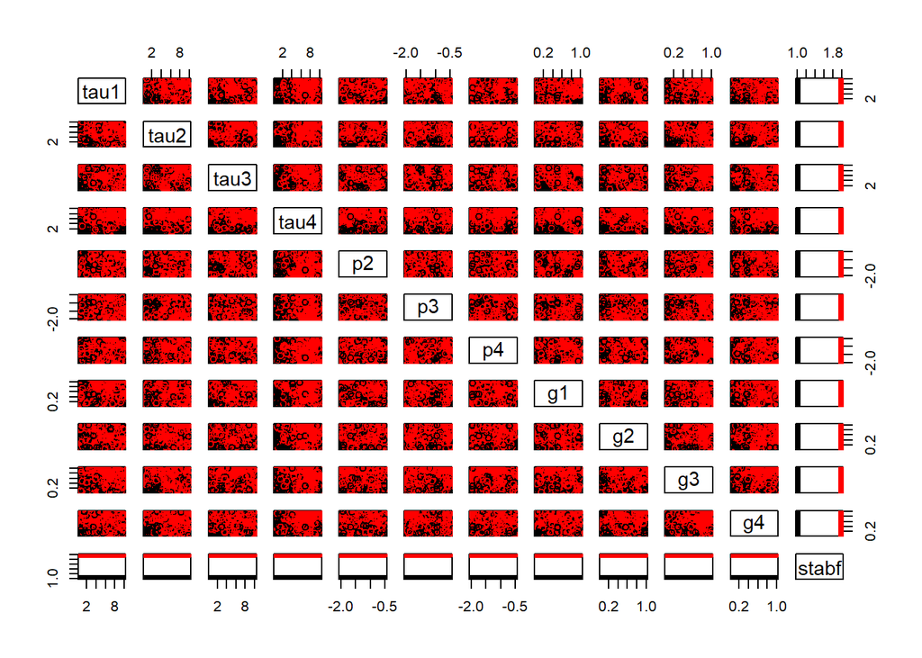

```r
pairs(data,col=data$stabf)
```

I used the pair() function to create a scatterplot matrix for all the variables. From the pair plot above, the red shows the distribution of observation with non-stable response while black shows distribution of observations with stable response.

```r
library(GGally)
```

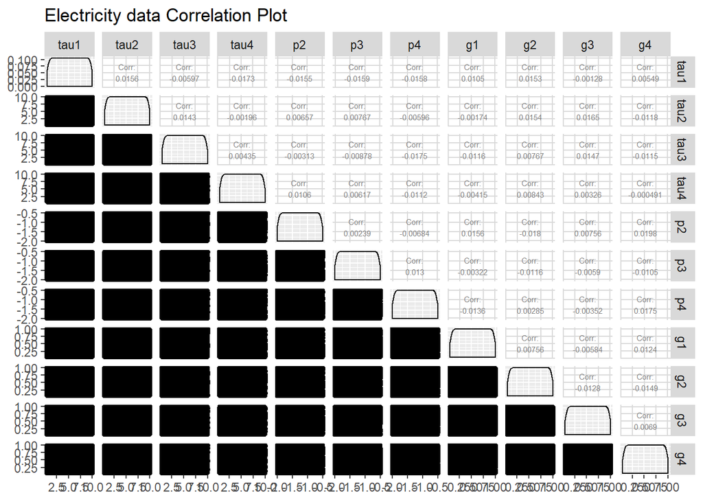

```r
ggpairs(data = data[1:11],
        title = "Electricity data Correlation Plot",
        upper = list(continuous = wrap("cor", size = 2)),
        lower = list(continuous = "smooth")
)
```

Use the plot() function to produce a scatter plot or the variable tau1

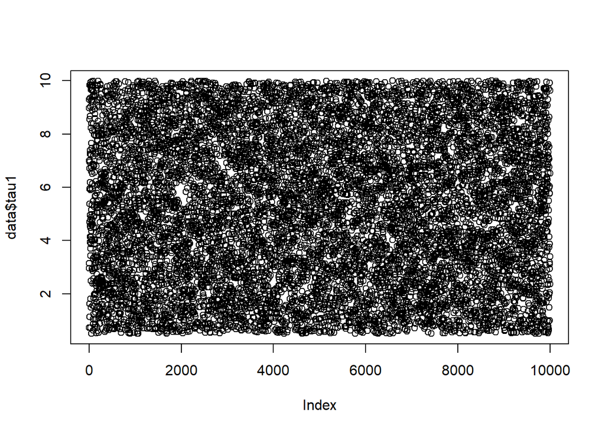

```r
plot(data$tau1)
```

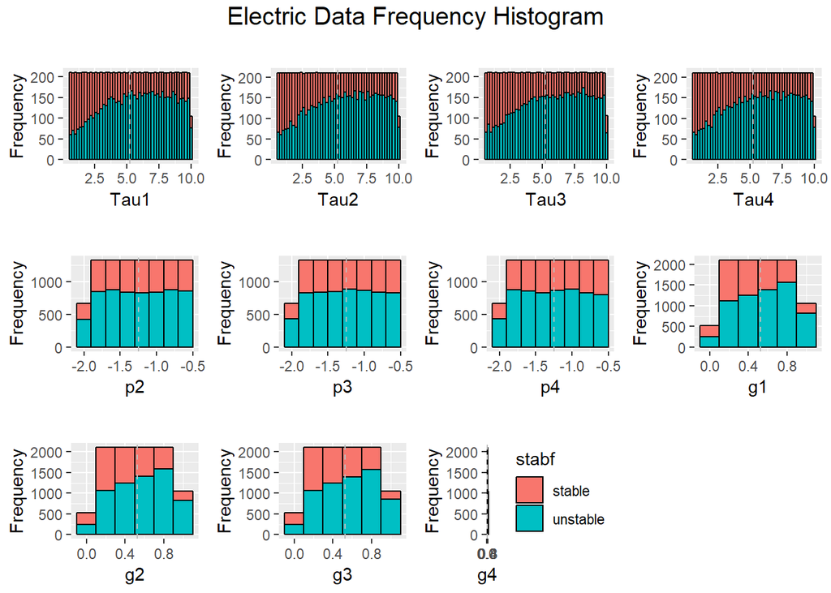

```r
library(ggplot2) # Data visualization
library(gridExtra)
library(grid)
# Density & Frequency analysis with the Histogram,

# Tau1
tau1l <- ggplot(data=data, aes(x=tau1))+
  geom_histogram(binwidth=0.2, color="black", aes(fill=stabf)) +
  xlab("Tau1") +
  ylab("Frequency") +
  theme(legend.position="none")+
  ggtitle("Histogram of Sepal Length")+
  geom_vline(data=data, aes(xintercept = mean(tau1)),linetype="dashed",color="grey")

# Tau2
tau2l <- ggplot(data=data, aes(x=tau2))+
  geom_histogram(binwidth=0.2, color="black", aes(fill=stabf)) +
  xlab("Tau2") +
  ylab("Frequency") +
  theme(legend.position="none")+
  ggtitle("Histogram of Sepal Length")+
  geom_vline(data=data, aes(xintercept = mean(tau2)),linetype="dashed",color="grey")

# Tau3
tau3l <- ggplot(data=data, aes(x=tau3))+
  geom_histogram(binwidth=0.2, color="black", aes(fill=stabf)) +
  xlab("Tau3") +
  ylab("Frequency") +
  theme(legend.position="none")+
  ggtitle("Histogram of Sepal Length")+
  geom_vline(data=data, aes(xintercept = mean(tau3)),linetype="dashed",color="grey")

# Tau4
tau4l <- ggplot(data=data, aes(x=tau2))+
  geom_histogram(binwidth=0.2, color="black", aes(fill=stabf)) +
  xlab("Tau4") +
  ylab("Frequency") +
  theme(legend.position="none")+
  ggtitle("Histogram of Sepal Length")+
  geom_vline(data=data, aes(xintercept = mean(tau4)),linetype="dashed",color="grey")

#P2
p2l <- ggplot(data=data, aes(x=p2))+
  geom_histogram(binwidth=0.2, color="black", aes(fill=stabf)) +
  xlab("p2") +
  ylab("Frequency") +
  theme(legend.position="none")+
  ggtitle("Histogram of Sepal Length")+
  geom_vline(data=data, aes(xintercept = mean(p2)),linetype="dashed",color="grey")

#P3
p3l <- ggplot(data=data, aes(x=p3))+
  geom_histogram(binwidth=0.2, color="black", aes(fill=stabf)) +
  xlab("p3") +
  ylab("Frequency") +
  theme(legend.position="none")+
  ggtitle("Histogram of Sepal Length")+
  geom_vline(data=data, aes(xintercept = mean(p3)),linetype="dashed",color="grey")

#P4
p4l <- ggplot(data=data, aes(x=p4))+
  geom_histogram(binwidth=0.2, color="black", aes(fill=stabf)) +
  xlab("p4") +
  ylab("Frequency") +
  theme(legend.position="none")+
  ggtitle("Histogram of Sepal Length")+
  geom_vline(data=data, aes(xintercept = mean(p4)),linetype="dashed",color="grey")

#g1
g1l <- ggplot(data=data, aes(x=g1))+
  geom_histogram(binwidth=0.2, color="black", aes(fill=stabf)) +
  xlab("g1") +
  ylab("Frequency") +
  theme(legend.position="none")+
  ggtitle("Histogram of Sepal Length")+
  geom_vline(data=data, aes(xintercept = mean(g1)),linetype="dashed",color="grey")

#g2
g2l <- ggplot(data=data, aes(x=g2))+
  geom_histogram(binwidth=0.2, color="black", aes(fill=stabf)) +
  xlab("g2") +
  ylab("Frequency") +
  theme(legend.position="none")+
  ggtitle("Histogram of Sepal Length")+
  geom_vline(data=data, aes(xintercept = mean(g2)),linetype="dashed",color="grey")

#g3
g3l <- ggplot(data=data, aes(x=g3))+
  geom_histogram(binwidth=0.2, color="black", aes(fill=stabf)) +
  xlab("g3") +
  ylab("Frequency") +
  theme(legend.position="none")+
  ggtitle("Histogram of Sepal Length")+
  geom_vline(data=data, aes(xintercept = mean(g3)),linetype="dashed",color="grey")

#g4
g4l <- ggplot(data=data, aes(x=g4))+
  geom_histogram(binwidth=0.2, color="black", aes(fill=stabf)) +
  xlab("g4") +
  ylab("Frequency") +
  theme(legend.position="right")+
  ggtitle("Histogram of Sepal Length")+
  geom_vline(data=data, aes(xintercept = mean(g4)),linetype="dashed",color="grey")

# Plot all visualizations
grid.arrange(tau1l + ggtitle(""),
             tau2l + ggtitle(""),
             tau3l + ggtitle(""),
             tau4l  + ggtitle(""),
             p2l + ggtitle(""),
             p3l + ggtitle(""),
             p4l + ggtitle(""),
             g1l + ggtitle(""),
             g2l + ggtitle(""),
             g3l + ggtitle(""),
             g4l + ggtitle(""),
             nrow = 3,
             top = textGrob("Electric Data Frequency Histogram",
                            gp=gpar(fontsize=15))
)
```

We can review the density distribution of each attribute broken down by class value. Like the scatterplot matrix, the density plot by class can help see the separation of classes. It can also help to understand the overlap in class values for an attribute.

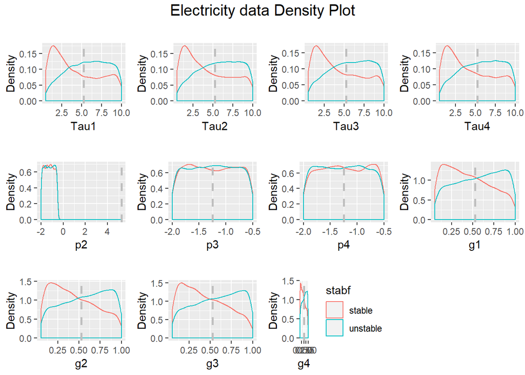

```r
# Tau1
tau1l <- ggplot(data=data, aes(x=tau1,colour=stabf), fill=stabf)+
  geom_density(alpha=.3) +
  geom_vline(aes(xintercept = mean(tau1), colour=stabf),linetype="dashed",color="grey",size=1)+
  xlab("Tau1") +
  ylab("Density") +
  theme(legend.position="none")

# Tau2
tau2l <- ggplot(data=data, aes(x=tau2,colour=stabf), fill=stabf)+
  geom_density(alpha=.3) +
  geom_vline(aes(xintercept = mean(tau2), colour=stabf),linetype="dashed",color="grey",size=1)+
  xlab("Tau2") +
  ylab("Density") +
  theme(legend.position="none")

# Tau3
tau3l <- ggplot(data=data, aes(x=tau3,colour=stabf), fill=stabf)+
  geom_density(alpha=.3) +
  geom_vline(aes(xintercept = mean(tau2), colour=stabf),linetype="dashed",color="grey",size=1)+
  xlab("Tau3") +
  ylab("Density") +
  theme(legend.position="none")

# Tau4
tau4l <- ggplot(data=data, aes(x=tau4,colour=stabf), fill=stabf)+
  geom_density(alpha=.3) +
  geom_vline(aes(xintercept = mean(tau4), colour=stabf),linetype="dashed",color="grey",size=1)+
  xlab("Tau4") +
  ylab("Density") +
  theme(legend.position="none")

#P2
p2l <- ggplot(data=data, aes(x=p2,colour=stabf), fill=stabf)+
  geom_density(alpha=.3) +
  geom_vline(aes(xintercept = mean(tau2), colour=stabf),linetype="dashed",color="grey",size=1)+
  xlab("p2") +
  ylab("Density") +
  theme(legend.position="none")

#P3
p3l <- ggplot(data=data, aes(x=p3,colour=stabf), fill=stabf)+
  geom_density(alpha=.3) +
  geom_vline(aes(xintercept = mean(p3), colour=stabf),linetype="dashed",color="grey",size=1)+
  xlab("p3") +
  ylab("Density") +
  theme(legend.position="none")

#P4
p4l <- ggplot(data=data, aes(x=p4,colour=stabf), fill=stabf)+
  geom_density(alpha=.3) +
  geom_vline(aes(xintercept = mean(p4), colour=stabf),linetype="dashed",color="grey",size=1)+
  xlab("p4") +
  ylab("Density") +
  theme(legend.position="none")

#g1
g1l <- ggplot(data=data, aes(x=g1,colour=stabf), fill=stabf)+
  geom_density(alpha=.3) +
  geom_vline(aes(xintercept = mean(g1), colour=stabf),linetype="dashed",color="grey",size=1)+
  xlab("g1") +
  ylab("Density") +
  theme(legend.position="none")

#g2
g2l <- ggplot(data=data, aes(x=g2,colour=stabf), fill=stabf)+
  geom_density(alpha=.3) +
  geom_vline(aes(xintercept = mean(g2), colour=stabf),linetype="dashed",color="grey",size=1)+
  xlab("g2") +
  ylab("Density") +
  theme(legend.position="none")

#g3
g3l <- ggplot(data=data, aes(x=g3,colour=stabf), fill=stabf)+
  geom_density(alpha=.3) +
  geom_vline(aes(xintercept = mean(g3), colour=stabf),linetype="dashed",color="grey",size=1)+
  xlab("g3") +
  ylab("Density") +
  theme(legend.position="none")

#g4
g4l <- ggplot(data=data, aes(x=g4,colour=stabf), fill=stabf)+
  geom_density(alpha=.3) +
  geom_vline(aes(xintercept = mean(g3), colour=stabf),linetype="dashed",color="grey",size=1)+
  xlab("g4") +
  ylab("Density") +
  theme(legend.position="right")

# Plot all density visualizations
grid.arrange(tau1l + ggtitle(""),
             tau2l + ggtitle(""),
             tau3l + ggtitle(""),
             tau4l + ggtitle(""),
             p2l + ggtitle(""),
             p3l + ggtitle(""),
             p4l + ggtitle(""),
             g1l + ggtitle(""),
             g2l + ggtitle(""),
             g3l + ggtitle(""),
             g4l + ggtitle(""),
             nrow = 3,
             top = textGrob("Electricity data Density Plot",
                            gp=gpar(fontsize=15))
)
```

Let’s plot all the variables in a single visualization that will contain all the boxplots

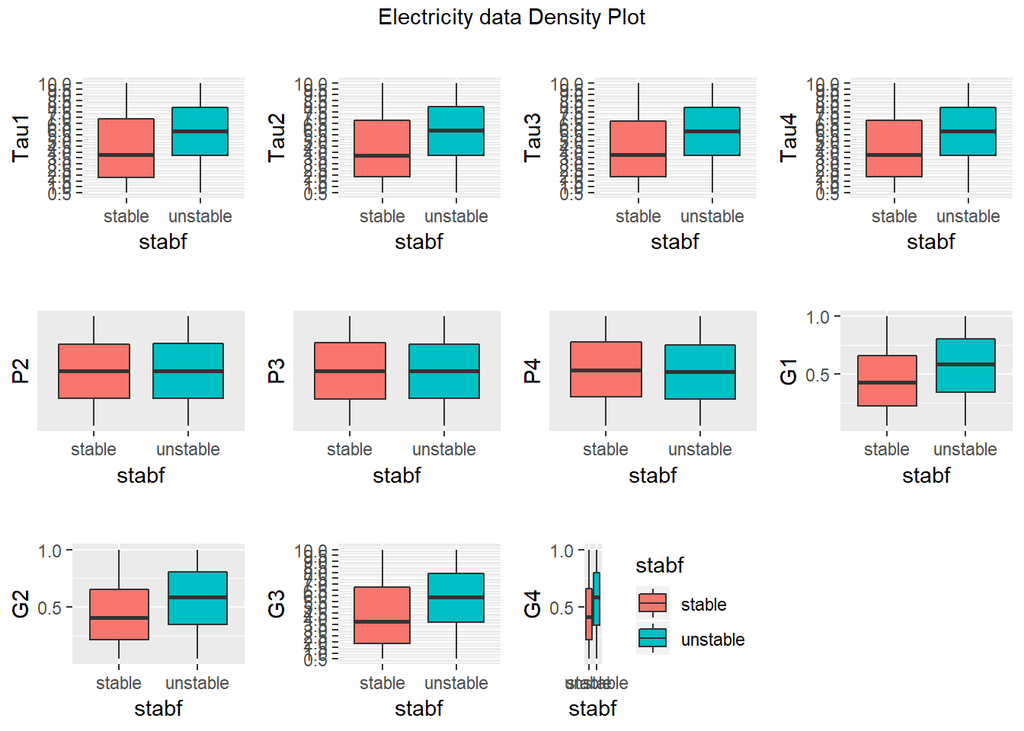

```r
tau1SL <- ggplot(data=data, aes(stabf,tau1,fill=stabf)) +
        geom_boxplot()+
        scale_y_continuous("Tau1", breaks= seq(0,300, by=.5))+
        theme(legend.position="none")

tau2SL <- ggplot(data=data, aes(stabf,tau2,fill=stabf)) +
        geom_boxplot()+
        scale_y_continuous("Tau2", breaks= seq(0,30, by=.5))+
        theme(legend.position="none")

tau3SL <- ggplot(data=data, aes(stabf,tau3,fill=stabf)) +
        geom_boxplot()+
        scale_y_continuous("Tau3", breaks= seq(0,30, by=.5))+
        theme(legend.position="none")
tau4SL <- ggplot(data=data, aes(stabf,tau4,fill=stabf)) +
        geom_boxplot()+
        scale_y_continuous("Tau4", breaks= seq(0,30, by=.5))+
        theme(legend.position="none")
p2SL <- ggplot(data=data, aes(stabf,p2,fill=stabf)) +
        geom_boxplot()+
        scale_y_continuous("P2", breaks= seq(0,30, by=.5))+
        theme(legend.position="none")
p3SL <- ggplot(data=data, aes(stabf,p3,fill=stabf)) +
        geom_boxplot()+
        scale_y_continuous("P3", breaks= seq(0,30, by=.5))+
        theme(legend.position="none")
p4SL <- ggplot(data=data, aes(stabf,p4,fill=stabf)) +
        geom_boxplot()+
        scale_y_continuous("P4", breaks= seq(0,30, by=.5))+
        theme(legend.position="none")
g1SL <- ggplot(data=data, aes(stabf,g1,fill=stabf)) +
        geom_boxplot()+
        scale_y_continuous("G1", breaks= seq(0,30, by=.5))+
        theme(legend.position="none")
g2SL <- ggplot(data=data, aes(stabf,g2,fill=stabf)) +
        geom_boxplot()+
        scale_y_continuous("G2", breaks= seq(0,30, by=.5))+
        theme(legend.position="none")
g3SL <- ggplot(data=data, aes(stabf,tau3,fill=stabf)) +
        geom_boxplot()+
        scale_y_continuous("G3", breaks= seq(0,30, by=.5))+
        theme(legend.position="none")

g4SL <- ggplot(data=data, aes(stabf,g4,fill=stabf)) +
        geom_boxplot()+
        scale_y_continuous("G4", breaks= seq(0,30, by=.5))+
        theme(legend.position="right")


# Plot all density visualizations
grid.arrange(tau1SL + ggtitle(""),
             tau2SL + ggtitle(""),
             tau3SL + ggtitle(""),
             tau4SL + ggtitle(""),
             p2SL + ggtitle(""),
             p3SL + ggtitle(""),
             p4SL + ggtitle(""),
             g1SL + ggtitle(""),
             g2SL + ggtitle(""),
             g3SL + ggtitle(""),
             g4SL + ggtitle(""),
             nrow = 3,
             top = textGrob("Electricity data Density Plot",
                            gp=gpar(fontsize=11))
)
```

# 2 Classification

## 2.1 Logistic Regression

### 2.1.1 Whole dataset for train and test

Now, I fit a logistic regression model in order to predict the stablity of the electricity using the predictive variables of the data. I used the generalized linear models glm() function. I used the whole dataset for the training of the model and testing of the model.

```r
glm.fits=glm(stabf~tau1+tau2+tau3+tau4+p2+p3+p4+g1+g2+g3+g4, family = binomial, data = data)
summary(glm.fits)
```

```
##
## Call:
## glm(formula = stabf ~ tau1 + tau2 + tau3 + tau4 + p2 + p3 + p4 +
##     g1 + g2 + g3 + g4, family = binomial, data = data)
##
## Deviance Residuals:
##     Min       1Q   Median       3Q      Max
## -3.0376  -0.5482   0.2220   0.6123   2.4797
##
## Coefficients:
##              Estimate Std. Error z value Pr(>|z|)
## (Intercept) -11.77892    0.28377 -41.509   <2e-16 ***
## tau1          0.31451    0.01129  27.847   <2e-16 ***
## tau2          0.32251    0.01139  28.316   <2e-16 ***
## tau3          0.31860    0.01139  27.961   <2e-16 ***
## tau4          0.33185    0.01147  28.935   <2e-16 ***
## p2            0.02298    0.06541   0.351    0.725
## p3            0.08092    0.06530   1.239    0.215
## p4           -0.09951    0.06486  -1.534    0.125
## g1            2.68809    0.11044  24.339   <2e-16 ***
## g2            2.91745    0.11225  25.991   <2e-16 ***
## g3            3.12533    0.11357  27.518   <2e-16 ***
## g4            2.85721    0.11183  25.550   <2e-16 ***
## ---
## Signif. codes:  0 '***' 0.001 '**' 0.01 '*' 0.05 '.' 0.1 ' ' 1
##
## (Dispersion parameter for binomial family taken to be 1)
##
##     Null deviance: 13091.2  on 9999  degrees of freedom
## Residual deviance:  7813.6  on 9988  degrees of freedom
## AIC: 7837.6
##
## Number of Fisher Scoring iterations: 6
```

The predictors with smallest p-value here are tau1,tau2,tau3,tau4,g1,g2,g3,g4. Shows these predictors have significance on the response variable stabf. p4 has negative coefficient which suggests a negative impact on the response variable.

Below used coef() function to access just the coefficients for this fitted model.

```r
coef(glm.fits)
```

```
##  (Intercept)         tau1         tau2         tau3         tau4
## -11.77891924   0.31450829   0.32250716   0.31859685   0.33184614
##           p2           p3           p4           g1           g2
##   0.02297856   0.08092072  -0.09951266   2.68808524   2.91744610
##           g3           g4
##   3.12533235   2.85720976
```

Below I used summary() function to access the p-values for the coefficients.

```r
summary(glm.fits)$coef
```

```
##                 Estimate Std. Error    z value      Pr(>|z|)
## (Intercept) -11.77891924 0.28376700 -41.509123  0.000000e+00
## tau1          0.31450829 0.01129408  27.847191 1.164890e-170
## tau2          0.32250716 0.01138952  28.316140 2.187206e-176
## tau3          0.31859685 0.01139431  27.961036 4.840376e-172
## tau4          0.33184614 0.01146848  28.935491 4.272833e-184
## p2            0.02297856 0.06540543   0.351325  7.253446e-01
## p3            0.08092072 0.06529729   1.239266  2.152470e-01
## p4           -0.09951266 0.06486296  -1.534199  1.249808e-01
## g1            2.68808524 0.11044424  24.338845 7.609620e-131
## g2            2.91744610 0.11224898  25.990847 6.284651e-149
## g3            3.12533235 0.11357489  27.517810 1.074926e-166
## g4            2.85720976 0.11182960  25.549673 5.536863e-144
```

Next I used the predict() function to prepedict the probability of the electricity stability, given the values of the predictors.

```r
glm.probs=predict(glm.fits,type = "response")
glm.probs[1:10]
```

```
##          1          2          3          4          5          6
## 0.99721229 0.84559325 0.69910272 0.73784670 0.98603349 0.51121102
##          7          8          9         10
## 0.64495319 0.82123837 0.01896633 0.94785159
```

```r
contrasts(data$stabf)
```

```
##          unstable
## stable          0
## unstable        1
```

The constrast() function assigned dummy variable 1 to unstable and 0 to stable. This shows that it predicts when the electricty grid will be unstable. The two commands below creates a vector of class predictions based whether the predicted probability of the Electricity grid non-stability is greater than or less than 0.5.

```r
glm.pred=rep("stable",10000)
glm.pred[glm.probs>.5]="unstable"
```

The first command creates a vector of 10000 stable elements. I used the second line to transform to unstable all elementsthat has probability that exceeds 0.5 table() function below was used to produce a confuse matrix to determine how many observations were correctly or incorrectly classified.

```r
table(glm.pred,data$stabf)
```

```
##
## glm.pred   stable unstable
##   stable     2556      771
##   unstable   1064     5609
```

```r
(2556+5609)/10000
```

```
## [1] 0.8165
```

```r
mean(glm.pred==data$stabf)
```

```
## [1] 0.8165
```

The mean() function can also be used to calculate the fraction of prediction correctness. Logistic regression correctly predicted the stability of the Electrict grid 81.7% of the time.

### 2.1.2 Train dataset and Held out dataset

Using the whole datset for both training the model and testing the model could be misleading. The train error rate tends to underestimate the test error rate. To solve this issue, I fitted the model using part of the data, and then examine how well it predits the held out data. This method is yields a more realistic error rate.

To implemented this strategy, I randomly divided the dataset into train data and test data.

```r
smp_siz = floor(0.75*nrow(data))
train_ind = sample(seq_len(nrow(data)),size = smp_siz)
train =data[train_ind,]
test=data[-train_ind,]
```

```r
glm.fits2=glm(stabf~tau1+tau2+tau3+tau4+p2+p3+p4+g1+g2+g3+g4, family = binomial, data = train)
summary(glm.fits2)
```

```
##
## Call:
## glm(formula = stabf ~ tau1 + tau2 + tau3 + tau4 + p2 + p3 + p4 +
##     g1 + g2 + g3 + g4, family = binomial, data = train)
##
## Deviance Residuals:
##     Min       1Q   Median       3Q      Max
## -3.0092  -0.5343   0.2196   0.6097   2.5378
##
## Coefficients:
##               Estimate Std. Error z value Pr(>|z|)
## (Intercept) -12.000268   0.332548 -36.086   <2e-16 ***
## tau1          0.320564   0.013202  24.281   <2e-16 ***
## tau2          0.341739   0.013426  25.454   <2e-16 ***
## tau3          0.311509   0.013234  23.538   <2e-16 ***
## tau4          0.330053   0.013263  24.886   <2e-16 ***
## p2            0.006359   0.076392   0.083    0.934
## p3            0.059233   0.075707   0.782    0.434
## p4           -0.111359   0.075766  -1.470    0.142
## g1            2.596050   0.128656  20.178   <2e-16 ***
## g2            2.977139   0.130763  22.767   <2e-16 ***
## g3            3.191587   0.131478  24.275   <2e-16 ***
## g4            2.952556   0.130566  22.613   <2e-16 ***
## ---
## Signif. codes:  0 '***' 0.001 '**' 0.01 '*' 0.05 '.' 0.1 ' ' 1
##
## (Dispersion parameter for binomial family taken to be 1)
##
##     Null deviance: 9778.0  on 7499  degrees of freedom
## Residual deviance: 5796.7  on 7488  degrees of freedom
## AIC: 5820.7
##
## Number of Fisher Scoring iterations: 6
```

Using the train data didnt change the predictors that are significant.The predictors with smallest p-value are still tau1,tau2,tau3,tau4,g1,g2,g3,g4. Also, this Shows these predictors have significance on the response variable stabf. p4 still has negative coefficient which suggests a negative impact on the response variable.

Next I used the predict() function to predict the probability of the electricity stability on new model using the test data, given the values of the predictors.

```r
glm.probs2=predict(glm.fits2,test,type = "response")
glm.probs2[1:10]
```

```
##          1          2          6          7          9         17
## 0.99715937 0.86039902 0.53391620 0.63108211 0.01861226 0.98509829
##         27         28         33         48
## 0.38608470 0.03680416 0.78623378 0.92484785
```

```r
contrasts(train$stabf)
```

```
##          unstable
## stable          0
## unstable        1
```

```r
dim(test)
```

```
## [1] 2500   12
```

The constrast() function assigned dummy variable 1 to unstable and 0 to stable. This shows that it predicts when the electricty grid will be unstable. the dim() funtion gets the ddimension of the test data. The two commands below creates a vector of class predictions based whether the predicted probability of the Electricity grid non-stability is greater than or less than 0.5 using the test data.

```r
glm.pred2=rep("stable",2500)
glm.pred2[glm.probs2>.5]="unstable"
```

```r
table(glm.pred2,test$stabf)
```

```
##
## glm.pred2  stable unstable
##   stable      673      222
##   unstable    267     1338
```

```r
glm_correctness = mean(glm.pred2==test$stabf)
glm_correctness
```

```
## [1] 0.8044
```

I used the mean() function to calculate the fraction of prediction correctness. The correctness using train data and test data is similar to when whole data was used for both train and test of model.

## 2.2 Linear Discriminant Analysis

I performed Linear Discriminant Analysis on the data. I fit an LDA model using lda() function. I fit the model using only the training data.

```r
require(MASS)
lda.fit=lda(stabf~tau1+tau2+tau3+tau4+p2+p3+p4+g1+g2+g3+g4,data=train)
lda.fit
```

```
## Call:
## lda(stabf ~ tau1 + tau2 + tau3 + tau4 + p2 + p3 + p4 + g1 + g2 +
##     g3 + g4, data = train)
##
## Prior probabilities of groups:
##    stable  unstable
## 0.3573333 0.6426667
##
## Group means:
##              tau1     tau2     tau3     tau4        p2        p3        p4
## stable   4.380537 4.330722 4.462437 4.400742 -1.245184 -1.250218 -1.239595
## unstable 5.734921 5.797430 5.754858 5.767394 -1.246395 -1.250423 -1.259762
##                 g1        g2        g3        g4
## stable   0.4575606 0.4491036 0.4388054 0.4486223
## unstable 0.5607578 0.5716775 0.5757179 0.5687910
##
## Coefficients of linear discriminants:
##                LD1
## tau1  0.1742414783
## tau2  0.1820879293
## tau3  0.1687140776
## tau4  0.1772510627
## p2   -0.0004786397
## p3    0.0338899823
## p4   -0.0606105693
## g1    1.3786905164
## g2    1.6058008024
## g3    1.7211687762
## g4    1.6034800989
```

Below plot() function produces a plot of the linear discriminants.

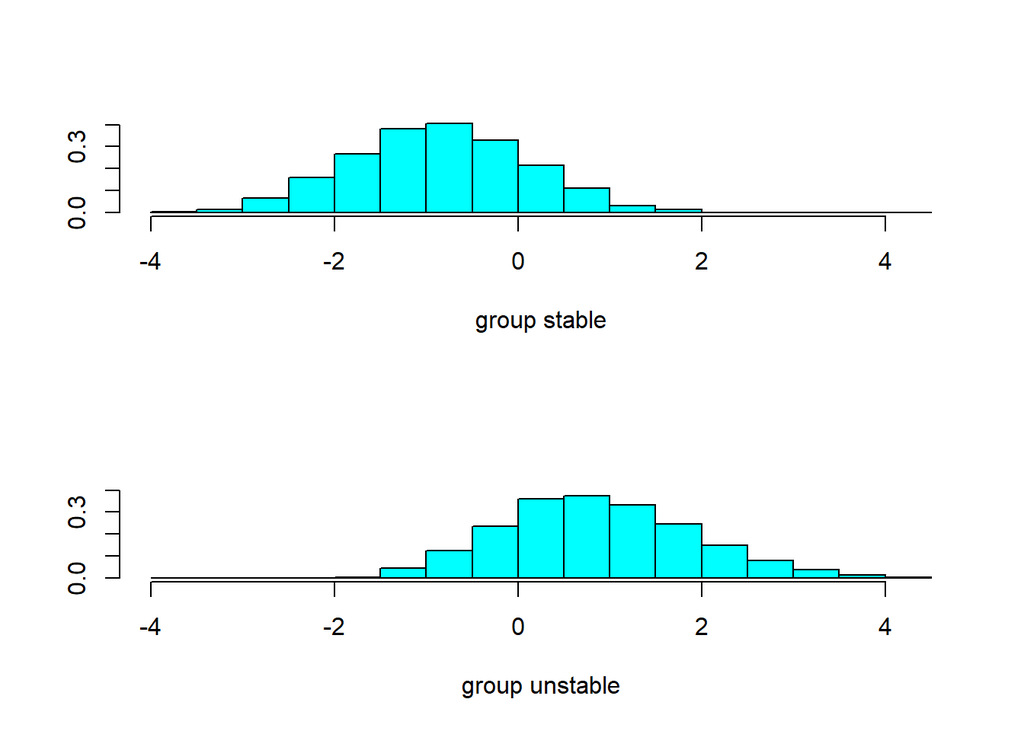

```r
plot(lda.fit)
```

Below is the predict() function which returns a list with three elements. Namely the class, posterior and x contains the linear discriminants. I used the test data with the predict() funtion

```r
lda.pred=predict(lda.fit, test)
names(lda.pred)
```

```
## [1] "class"     "posterior" "x"
```

Below contains getting the class and table() function below was used to produce a confuse matrix to determine how many observations were correctly or incorrectly classified

```r
lda.class=lda.pred$class
table(lda.class,test$stabf)
```

```
##
## lda.class  stable unstable
##   stable      675      225
##   unstable    265     1335
```

```r
lda_correctness=mean(lda.class==test$stabf)
lda_correctness
```

```
## [1] 0.804
```

I recreated the predictions contained in lda.pred$class using 50% threshold to the posterior probabilities.

```r
sum(lda.pred$posterior[,1]>=.5)
```

```
## [1] 900
```

```r
sum(lda.pred$posterior[,1]<.5)
```

```
## [1] 1600
```

## 2.3 Quadratic Discriminant Analysis

Also, I fit a QDA model to the Electricity grid data. Used a qda() function is R, which is part of the MASS library.

```r
qda.fit=qda(stabf~tau1+tau2+tau3+tau4+p2+p3+p4+g1+g2+g3+g4,data=train)
qda.fit
```

```
## Call:
## qda(stabf ~ tau1 + tau2 + tau3 + tau4 + p2 + p3 + p4 + g1 + g2 +
##     g3 + g4, data = train)
##
## Prior probabilities of groups:
##    stable  unstable
## 0.3573333 0.6426667
##
## Group means:
##              tau1     tau2     tau3     tau4        p2        p3        p4
## stable   4.380537 4.330722 4.462437 4.400742 -1.245184 -1.250218 -1.239595
## unstable 5.734921 5.797430 5.754858 5.767394 -1.246395 -1.250423 -1.259762
##                 g1        g2        g3        g4
## stable   0.4575606 0.4491036 0.4388054 0.4486223
## unstable 0.5607578 0.5716775 0.5757179 0.5687910
```

The output contains group means but doesnt contain coefficient of the linear discriminants. This is because its a not linear but quadratic.

Below, I used the predict() function which works same as in LDA.

```r
qda.class=predict(qda.fit,test)$class
table(qda.class,test$stabf)
```

```
##
## qda.class  stable unstable
##   stable      768      130
##   unstable    172     1430
```

```r
qda_correctness=mean(qda.class==test$stabf)
qda_correctness
```

```
## [1] 0.8792
```

## 2.4 K-Nearest Neighbors

I performed KNN using the knn() function. With knn it works differently from other model-fitting functions. Knn take a single command instead of the two-step train test approach.

I divided the data into train and test and I used normalization formular to conver everything into values between 0 and 1

```r
library(class)
train <- sample(1:nrow(data), 0.75 * nrow(data))
#test  <- data[-sample, ]

##the normalization function is created
nor <-function(x) { (x -min(x))/(max(x)-min(x))   }

##Run nomalization on first 11 coulumns of dataset because they are the predictors
data_norm <- as.data.frame(lapply(data[,c(1,2,3,4,5,6,7,8,9,10,11)], nor))

summary(data_norm)
```

```
##       tau1             tau2           tau3           tau4
##  Min.   :0.0000   Min.   :0.00   Min.   :0.00   Min.   :0.00
##  1st Qu.:0.2499   1st Qu.:0.25   1st Qu.:0.25   1st Qu.:0.25
##  Median :0.5000   Median :0.50   Median :0.50   Median :0.50
##  Mean   :0.5000   Mean   :0.50   Mean   :0.50   Mean   :0.50
##  3rd Qu.:0.7500   3rd Qu.:0.75   3rd Qu.:0.75   3rd Qu.:0.75
##  Max.   :1.0000   Max.   :1.00   Max.   :1.00   Max.   :1.00
##        p2               p3             p4             g1
##  Min.   :0.0000   Min.   :0.00   Min.   :0.00   Min.   :0.00
##  1st Qu.:0.2500   1st Qu.:0.25   1st Qu.:0.25   1st Qu.:0.25
##  Median :0.5000   Median :0.50   Median :0.50   Median :0.50
##  Mean   :0.5000   Mean   :0.50   Mean   :0.50   Mean   :0.50
##  3rd Qu.:0.7501   3rd Qu.:0.75   3rd Qu.:0.75   3rd Qu.:0.75
##  Max.   :1.0000   Max.   :1.00   Max.   :1.00   Max.   :1.00
##        g2             g3               g4
##  Min.   :0.00   Min.   :0.0000   Min.   :0.00
##  1st Qu.:0.25   1st Qu.:0.2500   1st Qu.:0.25
##  Median :0.50   Median :0.5000   Median :0.50
##  Mean   :0.50   Mean   :0.5000   Mean   :0.50
##  3rd Qu.:0.75   3rd Qu.:0.7499   3rd Qu.:0.75
##  Max.   :1.00   Max.   :1.0000   Max.   :1.00
```

I split the data into training and testing sets, the data is already normalized.

```r
##extract training set
data_train <- data_norm[train,]

##extract testing set
data_test <- data_norm[-train,]

##extract 5th column of train dataset because it will be used as 'cl' argument in knn function.
data_target_category <- data[train,12]
##extract 5th column if test dataset to measure the accuracy
data_test_category <- data[-train,12]
```

Below I used the knn() function to predict the stability of the Electricity grid. I set seed to 1 to ensure reproducibility of results.

```r
set.seed(1)
##run knn function
knn.pred <- knn(data_train,data_test,cl=data_target_category,k=1)
##create confusion matrix
table(knn.pred,data_test_category)
```

```
##           data_test_category
## knn.pred   stable unstable
##   stable      642      189
##   unstable    247     1422
```

```r
mean(knn.pred==data_test_category)
```

```
## [1] 0.8256
```

```r
set.seed(1)
##run knn function
knn.pred <- knn(data_train,data_test,cl=data_target_category,k=5)
##create confusion matrix
table(knn.pred,data_test_category)
```

```
##           data_test_category
## knn.pred   stable unstable
##   stable      662      108
##   unstable    227     1503
```

```r
knn_correctness=mean(knn.pred==data_test_category)
knn_correctness
```

```
## [1] 0.866
```

Comparing KNN with Logistic regression, LDA and QDA shows that QDA yielded a better result.

## 2.5 Comparing Logistic regression, LDA, QDA and KNN result

```r
data.frame(Logistic = glm_correctness, LDA = lda_correctness, QDA = qda_correctness, knn = knn_correctness)
```

```
##   Logistic   LDA    QDA   knn
## 1   0.8044 0.804 0.8792 0.866
```

# 3 Resampling Methods

Resmapling methods do with repeatedly drawing samples from a training set and refitting the model of interest on each sample in order to obtain additional information about the fitted model.

We used carryout cross-validation and the bootstrap methods.

## 3.1 Cross-Validation

The following sections describes the different cross-validation techniques.

### 3.1.1 The Validation set Approach

I am going to carry out the Validation set approach on the Electricity gride dataset. I use the set.seed() to random generate sample. I randomly divided the observations into 5000 train and 5000 validation set.

```r
set.seed(3)
smp_siz = floor(0.5*nrow(data))
train_ind = sample(seq_len(nrow(data)),size = smp_siz)
train =data[train_ind,]
validationSet=data[-train_ind,]
train_model=glm(stabf~tau1+tau2+tau3+tau4+p2+p3+p4+g1+g2+g3+g4, family = binomial,data = train)
```

```r
glm.probs=predict(train_model,validationSet,type = "response")
cont = contrasts(train$stabf)
glm.pred=rep("stable",5000)
glm.pred[glm.probs>.5]="unstable"
tlb = table(glm.pred,validationSet$stabf)
mean(glm.pred!=validationSet$stabf)
```

```
## [1] 0.1798
```

The Validation set error rate is 17.98%. Now, I will now use poly() function to estimate the test error for the quadratic and cubic classification.

```r
train_model2=glm(stabf~poly((tau1+tau2+tau3+tau4+p2+p3+p4+g1+g2+g3+g4),2), family = binomial,data = train)
glm.probs2=predict(train_model2,validationSet,type = "response")
cont2 = contrasts(train$stabf)
glm.pred2=rep("stable",5000)
glm.pred2[glm.probs2>.5]="unstable"
tlb2 = table(glm.pred2,validationSet$stabf)
mean(glm.pred2!=validationSet$stabf)
```

```
## [1] 0.2542
```

```r
train_model3=glm(stabf~poly((tau1+tau2+tau3+tau4+p2+p3+p4+g1+g2+g3+g4),3), family = binomial,data = train)
glm.probs3=predict(train_model3,validationSet,type = "response")
cont3 = contrasts(train$stabf)
glm.pred3=rep("stable",5000)
glm.pred3[glm.probs3>.5]="unstable"
tlb3 = table(glm.pred3,validationSet$stabf)
mean(glm.pred3!=validationSet$stabf)
```

```
## [1] 0.2538
```

Test error rate for Quadradic and cubic terms are 25.4 5 and 25.38% respectively. Using split of the observations into a training set and a validation set, I discovered the Validation set error rates for the model with linear, quadractic and cubic terms are 17.98, 25.42 and 25.38 respectively.

### 3.1.2 Leave-One-Out Cross-Validation (LOOCV)

I will use the cv.glm() function in boot lirary in R to carry out Leave-One-Out Cross-Vlidation. Logistic regression is use to ilustrate this aspect.

```r
#https://www.r-bloggers.com/predicting-creditability-using-logistic-regression-in-r-cross-validating-the-classifier-part-2-2/
library(boot)
# Cost function for a binary classifier suggested by boot package
cost <- function(r, pi = 0) mean(abs(r-pi) > 0.5)
model=glm(stabf~tau1+tau2+tau3+tau4+p2+p3+p4+g1+g2+g3+g4, family = binomial, data = data)
cv.error1=cv.glm(data,model,cost=cost)
cv.error1$delta
```

```
## [1] 0.1841000 0.1840737
```

From above, the delta vector contains the cross-validation results. The two numbers in the delta vector contain the cross-validation results. The number we are 0.1841000, 0.1840737. The cross-validation estimate for the test error is approximately 0.184.

Will repeat this procedure from increasingly complex polynomial fits.

```r
# Cost function for a binary classifier suggested by boot package
cv.error=rep(0,5)
for(i in 1:5){
  model=glm(stabf~poly((tau1+tau2+tau3+tau4+p2+p3+p4+g1+g2+g3+g4),i), family = binomial, data = data)
  cv.error[i]=cv.glm(data,model,cost=cost)$delta[1]
}

cv.error
```

```
## [1] 0.2532 0.2543 0.2539 0.2540 0.2541
```

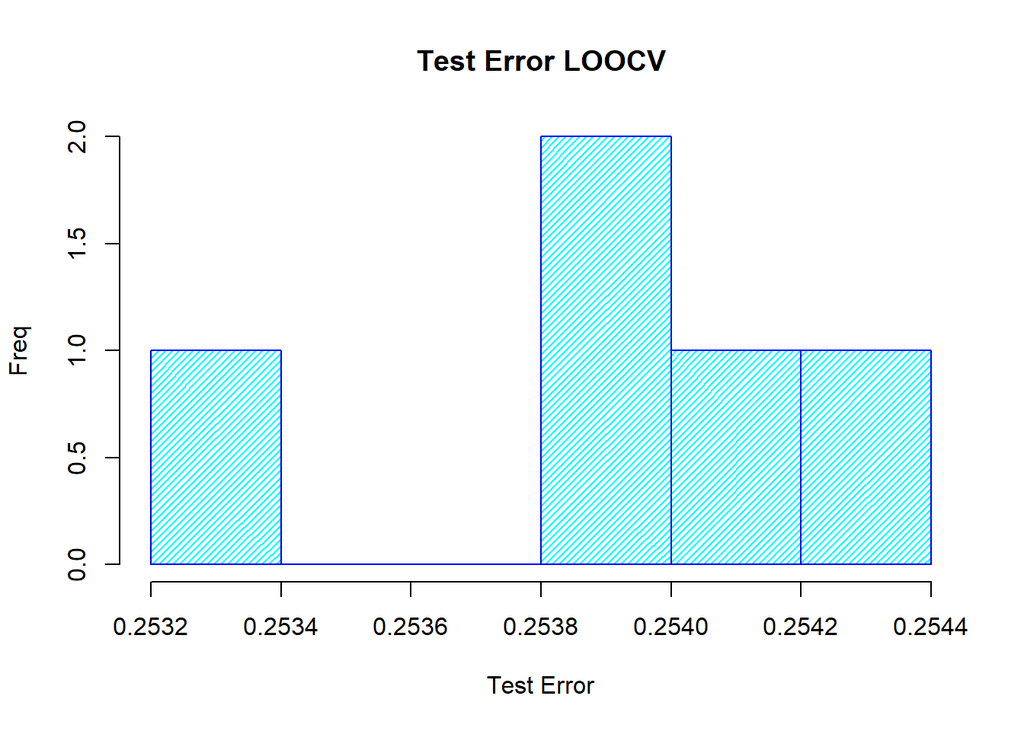

```r
# Histogram of the Test Error
hist(cv.error,xlab='Test Error',ylab='Freq',main='Test Error LOOCV',
     col='cyan',border='blue',density=30)
```

From above procedure, used for loop to iteratively fit polynomial regressions for polynomial of order i = 1 to i=5. Computes the cross-validation.

### 3.1.3 K-fOLD Cross-Validation

For K-Fold Cross-Validation, we can also use cv.glm() function to implement k-fold CV. I will K = 5 first and also use k=10. For both procedure, will get CV errors corresponding to polynomial fits for orders 1 to 10.

```r
set.seed(17)
cv.error.5=rep(0,10)
for(i in 1:10){
  model=glm(stabf~poly((tau1+tau2+tau3+tau4+p2+p3+p4+g1+g2+g3+g4),i), family = binomial, data = data)
  cv.error.5[i]=cv.glm(data,model,K=5,cost=cost)$delta[1]
}

cv.error.5
```

```
##  [1] 0.2541 0.2534 0.2532 0.2531 0.2538 0.2541 0.2532 0.2537 0.2529 0.2875
```

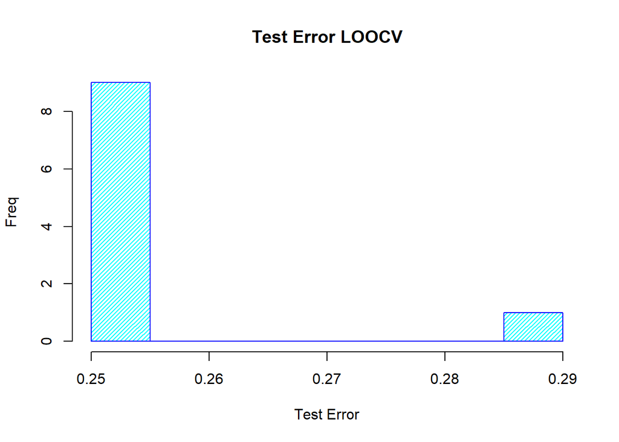

```r
# Histogram of the Test Error
hist(cv.error.5,xlab='Test Error',ylab='Freq',main='Test Error LOOCV',
     col='cyan',border='blue',density=30)
```

```r
set.seed(17)
cv.error.10=rep(0,10)
for(i in 1:10){
  model=glm(stabf~poly((tau1+tau2+tau3+tau4+p2+p3+p4+g1+g2+g3+g4),i), family = binomial, data = data)
  cv.error.10[i]=cv.glm(data,model,K=10,cost=cost)$delta[1]
}

cv.error.10
```

```
##  [1] 0.2533 0.2538 0.2532 0.2537 0.2543 0.2540 0.2536 0.2548 0.2536 0.2537
```

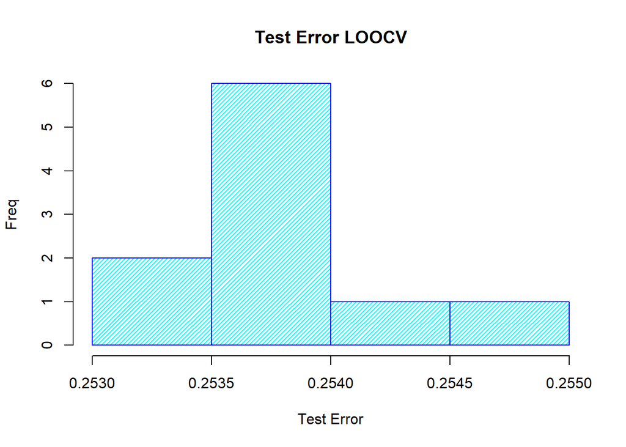

```r
# Histogram of the Test Error
hist(cv.error.10,xlab='Test Error',ylab='Freq',main='Test Error LOOCV',
     col='cyan',border='blue',density=30)
```

### 3.1.4 The Bootstrap

```r
# load the library
library(caret)
library(e1071)
# load the iris dataset
# define training control
train_control <- trainControl(method="boot", number=100)
# train the model
model <- train(stabf~., data=data, trControl=train_control, method="glm")
# summarize results
print(model)
```

```
## Generalized Linear Model
##
## 10000 samples
##    11 predictor
##     2 classes: 'stable', 'unstable'
##
## No pre-processing
## Resampling: Bootstrapped (100 reps)
## Summary of sample sizes: 10000, 10000, 10000, 10000, 10000, 10000, ...
## Resampling results:
##
##   Accuracy   Kappa
##   0.8155133  0.593465
```

```r
set.seed(1)

boot.fn=function(data,index){
  model=glm(stabf~tau1+tau2+tau3+tau4+p2+p3+p4+g1+g2+g3+g4, family = binomial, data = data,subset = index)
  return(coef(model))
}

boot.fn(data,sample(392,392,replace = T))
```

```
##   (Intercept)          tau1          tau2          tau3          tau4
## -11.028389517   0.292196397   0.324862455   0.205533802   0.327012711
##            p2            p3            p4            g1            g2
##  -0.007557283   0.263152346  -0.334260753   1.739338121   2.898179446
##            g3            g4
##   3.184296757   3.175513867
```

```r
boot(data,boot.fn,1000)
```

```
##
## ORDINARY NONPARAMETRIC BOOTSTRAP
##
##
## Call:
## boot(data = data, statistic = boot.fn, R = 1000)
##
##
## Bootstrap Statistics :
##          original        bias    std. error
## t1*  -11.77891924 -3.141154e-02  0.28356410
## t2*    0.31450829  4.606738e-04  0.01172524
## t3*    0.32250716  8.701986e-04  0.01216134
## t4*    0.31859685  7.105152e-04  0.01164373
## t5*    0.33184614  1.055868e-03  0.01174886
## t6*    0.02297856  1.876197e-03  0.06713454
## t7*    0.08092072 -3.563465e-03  0.06519611
## t8*   -0.09951266 -6.855842e-05  0.06357194
## t9*    2.68808524  6.250132e-03  0.11589781
## t10*   2.91744610  2.544534e-03  0.11549954
## t11*   3.12533235  4.673121e-03  0.11373222
## t12*   2.85720976  1.688370e-02  0.11440168
```

# 4 Model Selection and Regularization

## 4.1 Subset Selection

### 4.1.1 Best Subset Selection

I apply the best subset seletion approach to the Electricity data. An R package that will do subset selection for logistic regression is the bestglm package. This package is dependent on the leaps package that is used for linear regression but can also be used for logistic regression.

```r
library(leaps)
regfit.full = regsubsets(stabf~.,data)
summary(regfit.full)
```

```
## Subset selection object
## Call: regsubsets.formula(stabf ~ ., data)
## 11 Variables  (and intercept)
##      Forced in Forced out
## tau1     FALSE      FALSE
## tau2     FALSE      FALSE
## tau3     FALSE      FALSE
## tau4     FALSE      FALSE
## p2       FALSE      FALSE
## p3       FALSE      FALSE
## p4       FALSE      FALSE
## g1       FALSE      FALSE
## g2       FALSE      FALSE
## g3       FALSE      FALSE
## g4       FALSE      FALSE
## 1 subsets of each size up to 8
## Selection Algorithm: exhaustive
##          tau1 tau2 tau3 tau4 p2  p3  p4  g1  g2  g3  g4
## 1  ( 1 ) " "  "*"  " "  " "  " " " " " " " " " " " " " "
## 2  ( 1 ) " "  "*"  " "  "*"  " " " " " " " " " " " " " "
## 3  ( 1 ) "*"  "*"  " "  "*"  " " " " " " " " " " " " " "
## 4  ( 1 ) "*"  "*"  "*"  "*"  " " " " " " " " " " " " " "
## 5  ( 1 ) "*"  "*"  "*"  "*"  " " " " " " " " " " "*" " "
## 6  ( 1 ) "*"  "*"  "*"  "*"  " " " " " " " " "*" "*" " "
## 7  ( 1 ) "*"  "*"  "*"  "*"  " " " " " " " " "*" "*" "*"
## 8  ( 1 ) "*"  "*"  "*"  "*"  " " " " " " "*" "*" "*" "*"
```

Asterish indicates that a given variable is included in the corresponding model. From above, the output indicates that the best one-variable model contains taus2. Best two-variable model contains only tau2 and tau4, best three-variable model contains tau1,tau2 and tau4.

Will run the same procedure agaib but this time add parameter nvmax to get up to sbset 11.

```r
library(leaps)
regfit.full = regsubsets(stabf~.,data,nvmax = 11)
summary(regfit.full)
```

```
## Subset selection object
## Call: regsubsets.formula(stabf ~ ., data, nvmax = 11)
## 11 Variables  (and intercept)
##      Forced in Forced out
## tau1     FALSE      FALSE
## tau2     FALSE      FALSE
## tau3     FALSE      FALSE
## tau4     FALSE      FALSE
## p2       FALSE      FALSE
## p3       FALSE      FALSE
## p4       FALSE      FALSE
## g1       FALSE      FALSE
## g2       FALSE      FALSE
## g3       FALSE      FALSE
## g4       FALSE      FALSE
## 1 subsets of each size up to 11
## Selection Algorithm: exhaustive
##           tau1 tau2 tau3 tau4 p2  p3  p4  g1  g2  g3  g4
## 1  ( 1 )  " "  "*"  " "  " "  " " " " " " " " " " " " " "
## 2  ( 1 )  " "  "*"  " "  "*"  " " " " " " " " " " " " " "
## 3  ( 1 )  "*"  "*"  " "  "*"  " " " " " " " " " " " " " "
## 4  ( 1 )  "*"  "*"  "*"  "*"  " " " " " " " " " " " " " "
## 5  ( 1 )  "*"  "*"  "*"  "*"  " " " " " " " " " " "*" " "
## 6  ( 1 )  "*"  "*"  "*"  "*"  " " " " " " " " "*" "*" " "
## 7  ( 1 )  "*"  "*"  "*"  "*"  " " " " " " " " "*" "*" "*"
## 8  ( 1 )  "*"  "*"  "*"  "*"  " " " " " " "*" "*" "*" "*"
## 9  ( 1 )  "*"  "*"  "*"  "*"  " " " " "*" "*" "*" "*" "*"
## 10  ( 1 ) "*"  "*"  "*"  "*"  " " "*" "*" "*" "*" "*" "*"
## 11  ( 1 ) "*"  "*"  "*"  "*"  "*" "*" "*" "*" "*" "*" "*"
```

p2 is the last variable to be added at subset 11. This agrees with our earlier discovery showing p2 with high p-value, showing its less significance.

```r
names(summary(regfit.full))
```

```
## [1] "which"  "rsq"    "rss"    "adjr2"  "cp"     "bic"    "outmat" "obj"
```

The summary() function returns R2, RSS, adjusted R2, Cp, and BIC.We can examine these to try to select the best overall model.

```r
reg.summary=summary(regfit.full)
reg.summary$rsq  #summary of the R-squares for all 11 variables
```

```
##  [1] 0.06065381 0.11818622 0.17353206 0.22847314 0.27862044 0.32238730
##  [7] 0.36680626 0.40540054 0.40553756 0.40561033 0.40561173
```

Below I plot RSS, adjusted Rs,Cp and BIC for all of the models.

```
## [1] 10
```

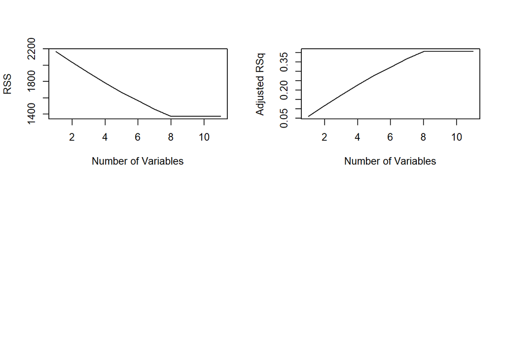

```r
# Plot RSS, adjusted r-square, Cp, BIC for all the models at once
par(mfrow = c(2, 2))
# RSS Plot
plot(reg.summary$rss, xlab = "Number of Variables", ylab = "RSS", type = "l")
# Adjusted RSq plot
plot(reg.summary$adjr2, xlab = "Number of Variables", ylab = "Adjusted RSq",
    type = "l")
which.max(reg.summary$adjr2)
```

```r
par(mfrow=c(2,2))
plot(reg.summary$rss, xlab = "Number of Variables", ylab = "RSS", type = "l")
plot(reg.summary$adjr2, xlab = "Number of Variables", ylab = "Adjusted RSq", type = "l")
which.max(reg.summary$adjr2)
```

```
## [1] 10
```

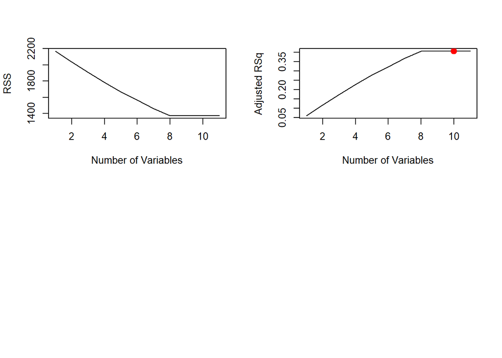

```r
points(10, reg.summary$adjr2[10], col = "red", cex = 2, pch = 20)
```

Also, I will plt Cp and BIC Statistics and indicates model with smallest statistics.

```r
par(mfrow=c(2,2))
plot(reg.summary$cp, xlab = "Number of Variables", ylab = "Cp", type = "l")
which.min(reg.summary$cp)
```

```
## [1] 9
```

```r
points(9, reg.summary$cp[9], col = "red", cex = 2, pch = 20)
which.min(reg.summary$bic)
```

```
## [1] 8
```

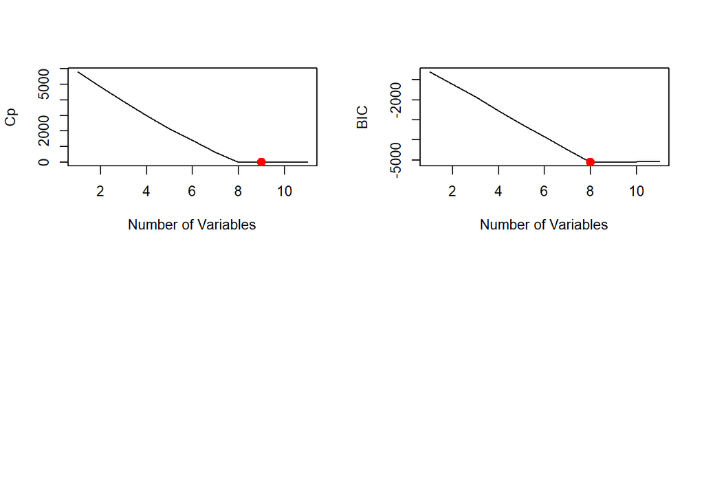

```r
plot(reg.summary$bic, xlab = "Number of Variables", ylab = "BIC", type = "l")
points(8, reg.summary$bic[8], col = "red", cex = 2, pch = 20)
```

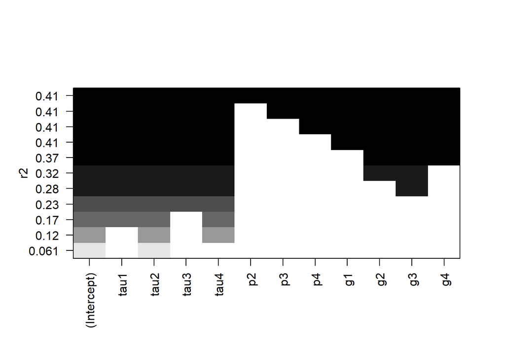

```r
plot(regfit.full,scale ="r2")
```

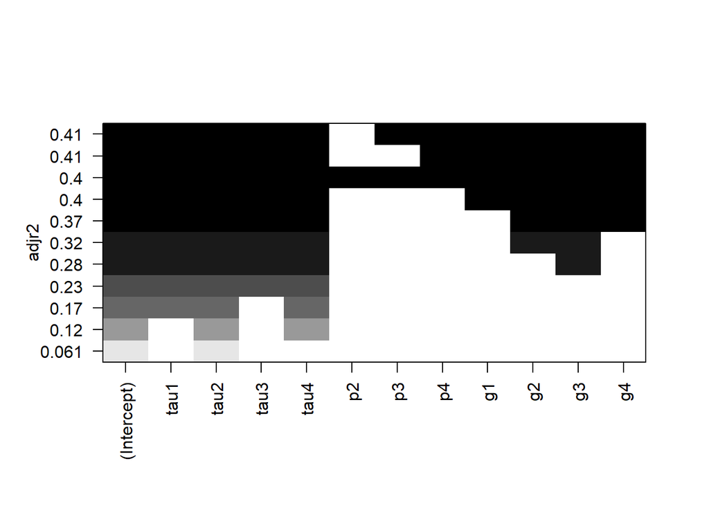

```r
plot(regfit.full,scale ="adjr2")
```

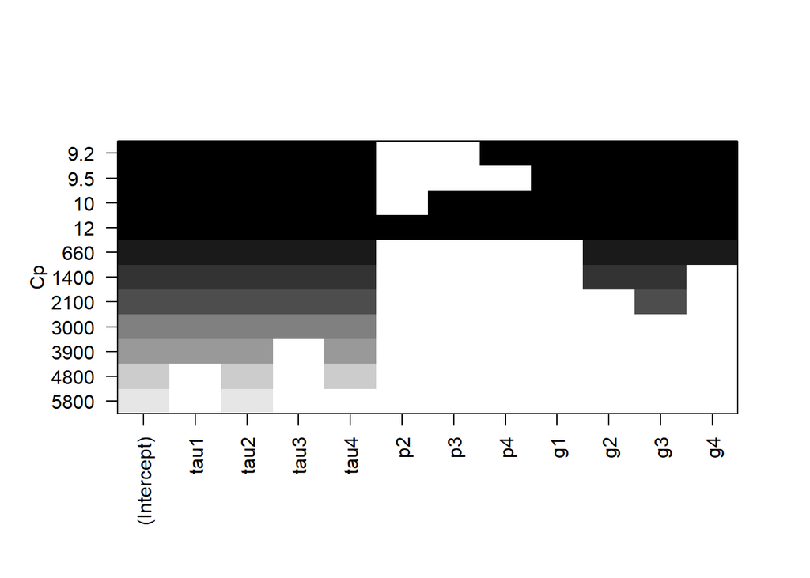

```r
plot(regfit.full,scale ="Cp")
```

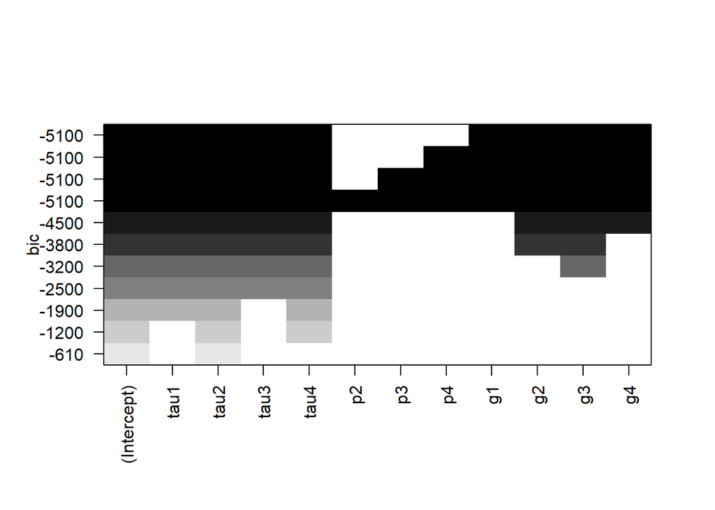

```r
plot(regfit.full,scale ="bic")
```

The top row of each plot contains a black square for each variable selected according to the optimal model associated with that statistic. Coef can be used to see which coefficient estimates associated with this model.

```r
coef(regfit.full,8)
```

```
##  (Intercept)         tau1         tau2         tau3         tau4
## -0.003073225  0.040415194  0.041291656  0.041038582  0.042267964
##           g1           g2           g3           g4
##  0.344351235  0.369522837  0.396671063  0.365174195
```

From above, its shown that the model with the smallest BIC close to -5100 is the eight-variable model that cntains only tau1, tau2, tau3, tau4, g1, g2g3 and g4.

### 4.1.2 Stepwise Selection

#### 4.1.2.1 Forward Stepwise Selection

The regsubsets() function can also be used for forward stepwise selection, by adding the parameter method=“forward”.

```r
regfit.full = regsubsets(stabf~.,data,nvmax = 11, method = "forward")
summary(regfit.full)
```

```
## Subset selection object
## Call: regsubsets.formula(stabf ~ ., data, nvmax = 11, method = "forward")
## 11 Variables  (and intercept)
##      Forced in Forced out
## tau1     FALSE      FALSE
## tau2     FALSE      FALSE
## tau3     FALSE      FALSE
## tau4     FALSE      FALSE
## p2       FALSE      FALSE
## p3       FALSE      FALSE
## p4       FALSE      FALSE
## g1       FALSE      FALSE
## g2       FALSE      FALSE
## g3       FALSE      FALSE
## g4       FALSE      FALSE
## 1 subsets of each size up to 11
## Selection Algorithm: forward
##           tau1 tau2 tau3 tau4 p2  p3  p4  g1  g2  g3  g4
## 1  ( 1 )  " "  "*"  " "  " "  " " " " " " " " " " " " " "
## 2  ( 1 )  " "  "*"  " "  "*"  " " " " " " " " " " " " " "
## 3  ( 1 )  "*"  "*"  " "  "*"  " " " " " " " " " " " " " "
## 4  ( 1 )  "*"  "*"  "*"  "*"  " " " " " " " " " " " " " "
## 5  ( 1 )  "*"  "*"  "*"  "*"  " " " " " " " " " " "*" " "
## 6  ( 1 )  "*"  "*"  "*"  "*"  " " " " " " " " "*" "*" " "
## 7  ( 1 )  "*"  "*"  "*"  "*"  " " " " " " " " "*" "*" "*"
## 8  ( 1 )  "*"  "*"  "*"  "*"  " " " " " " "*" "*" "*" "*"
## 9  ( 1 )  "*"  "*"  "*"  "*"  " " " " "*" "*" "*" "*" "*"
## 10  ( 1 ) "*"  "*"  "*"  "*"  " " "*" "*" "*" "*" "*" "*"
## 11  ( 1 ) "*"  "*"  "*"  "*"  "*" "*" "*" "*" "*" "*" "*"
```

Following the above forward stepwise selection, the best one variable model contains only tau2, and the best two-variable contains taus and tau4 and so on. Due to the nature of my data, the result of forward stepwise is similar to what we got with best stepwise.

#### 4.1.2.2 Backward Stepwise Selection

The regsubsets() function can also be used for backward stepwise selection, by adding the parameter method=“backward”.

```r
regfit.full = regsubsets(stabf~.,data,nvmax = 11, method = "backward")
summary(regfit.full)
```

```
## Subset selection object
## Call: regsubsets.formula(stabf ~ ., data, nvmax = 11, method = "backward")
## 11 Variables  (and intercept)
##      Forced in Forced out
## tau1     FALSE      FALSE
## tau2     FALSE      FALSE
## tau3     FALSE      FALSE
## tau4     FALSE      FALSE
## p2       FALSE      FALSE
## p3       FALSE      FALSE
## p4       FALSE      FALSE
## g1       FALSE      FALSE
## g2       FALSE      FALSE
## g3       FALSE      FALSE
## g4       FALSE      FALSE
## 1 subsets of each size up to 11
## Selection Algorithm: backward
##           tau1 tau2 tau3 tau4 p2  p3  p4  g1  g2  g3  g4
## 1  ( 1 )  " "  "*"  " "  " "  " " " " " " " " " " " " " "
## 2  ( 1 )  " "  "*"  " "  "*"  " " " " " " " " " " " " " "
## 3  ( 1 )  "*"  "*"  " "  "*"  " " " " " " " " " " " " " "
## 4  ( 1 )  "*"  "*"  "*"  "*"  " " " " " " " " " " " " " "
## 5  ( 1 )  "*"  "*"  "*"  "*"  " " " " " " " " " " "*" " "
## 6  ( 1 )  "*"  "*"  "*"  "*"  " " " " " " " " "*" "*" " "
## 7  ( 1 )  "*"  "*"  "*"  "*"  " " " " " " " " "*" "*" "*"
## 8  ( 1 )  "*"  "*"  "*"  "*"  " " " " " " "*" "*" "*" "*"
## 9  ( 1 )  "*"  "*"  "*"  "*"  " " " " "*" "*" "*" "*" "*"
## 10  ( 1 ) "*"  "*"  "*"  "*"  " " "*" "*" "*" "*" "*" "*"
## 11  ( 1 ) "*"  "*"  "*"  "*"  "*" "*" "*" "*" "*" "*" "*"
```

Result I ordained is similar to forward stepwise and backward stepwise. Though won’t always be the case.

## 4.2 Shrinkage Methods

The R package glmnet will be used to perform both ridge regression model and lasso models.

```r
# Split the data into training and test set
#install.packages("magrittr") # only needed the first time you use it
#install.packages("dplyr")    # alternative installation of the %>%
library(magrittr) # need to run every time you start R and want to use %>%
library(dplyr)    # alternative, this also loads %>%
library(caret)
library(glmnet)
set.seed(123)
training.samples <- data$stabf %>%
  createDataPartition(p = 0.8, list = FALSE)
train.data  <- data[training.samples, ]
test.data <- data[-training.samples, ]


# Find the best lambda using cross-validation
set.seed(123)
# Dumy code categorical predictor variables
x <- model.matrix(stabf~., train.data)[,-1]
# Convert the outcome (class) to a numerical variable
y <- ifelse(train.data$stabf == "stable", 1, 0)


cv.ridge <- cv.glmnet(x, y, alpha = 0, family = "binomial")
# Fit the final model on the training data
model <- glmnet(x, y, alpha = 1, family = "binomial",
                lambda = cv.ridge$lambda.min)
# Display regression coefficients
coef(model)
```

```
## 12 x 1 sparse Matrix of class "dgCMatrix"
##                     s0
## (Intercept)  8.4020556
## tau1        -0.2365165
## tau2        -0.2380509
## tau3        -0.2330998
## tau4        -0.2347727
## p2           .
## p3           .
## p4           .
## g1          -1.8894645
## g2          -2.0506054
## g3          -2.2428720
## g4          -2.0522462
```

```r
# Make predictions on the test data
x.test <- model.matrix(stabf ~., test.data)[,-1]
probabilities <- model %>% predict(newx = x.test)
predicted.classes <- ifelse(probabilities > 0.5, "stable", "unstable")
# Model accuracy
observed.classes <- test.data$stabf
mean(predicted.classes == observed.classes)
```

```
## [1] 0.815
```

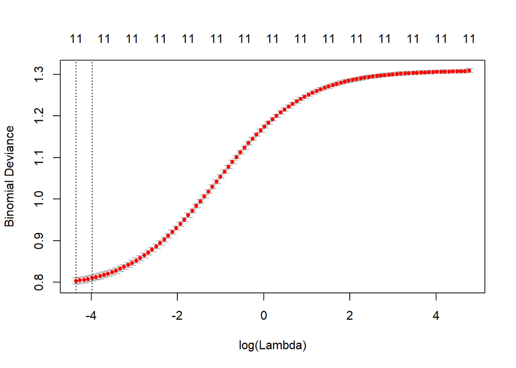

```r
plot(cv.ridge)
```

### 4.2.2 The Lasso

```r
# Split the data into training and test set
#install.packages("magrittr") # only needed the first time you use it
#install.packages("dplyr")    # alternative installation of the %>%
library(magrittr) # need to run every time you start R and want to use %>%
library(dplyr)    # alternative, this also loads %>%
library(caret)
set.seed(123)
training.samples <- data$stabf %>%
  createDataPartition(p = 0.8, list = FALSE)
train.data  <- data[training.samples, ]
test.data <- data[-training.samples, ]


# Find the best lambda using cross-validation
set.seed(123)
# Dumy code categorical predictor variables
x <- model.matrix(stabf~., train.data)[,-1]
# Convert the outcome (class) to a numerical variable
y <- ifelse(train.data$stabf == "stable", 1, 0)


cv.lasso <- cv.glmnet(x, y, alpha = 1, family = "binomial")
# Fit the final model on the training data
model <- glmnet(x, y, alpha = 1, family = "binomial",
                lambda = cv.lasso$lambda.min)
# Display regression coefficients
coef(model)
```

```
## 12 x 1 sparse Matrix of class "dgCMatrix"
##                      s0
## (Intercept) 11.39079462
## tau1        -0.31482599
## tau2        -0.31660179
## tau3        -0.31178392
## tau4        -0.31517472
## p2          -0.03925336
## p3          -0.08143423
## p4           0.07529571
## g1          -2.59707958
## g2          -2.79362124
## g3          -3.02222301
## g4          -2.79597452
```

```r
# Make predictions on the test data
x.test <- model.matrix(stabf ~., test.data)[,-1]
probabilities <- model %>% predict(newx = x.test)
predicted.classes <- ifelse(probabilities > 0.5, "stable", "unstable")
# Model accuracy
observed.classes <- test.data$stabf
mean(predicted.classes == observed.classes)
```

```
## [1] 0.8195
```

Find the optimal value of lambda that minimizes the cross-validation error:

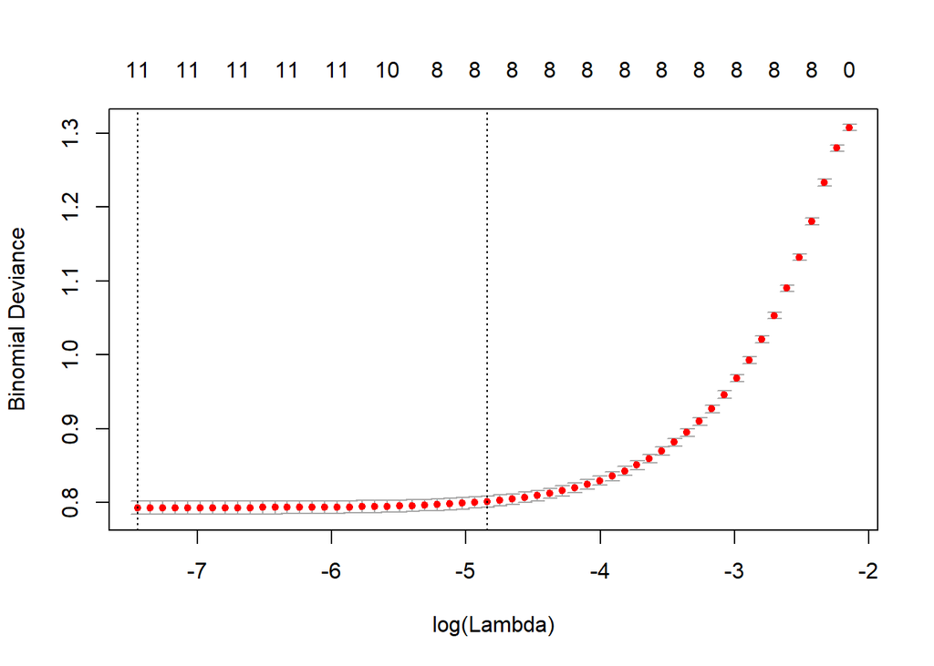

```r
set.seed(123)
cv.lasso <- cv.glmnet(x, y, alpha = 1, family = "binomial")
plot(cv.lasso)
```